# Data Summary

Occurrence data overview for SDM

Published

April 30, 2026

# Dataset overview

```r
summary_stats <- tibble(
  Metric = c(
    "Total Records",
    "Records with Valid Coordinates",
    "Unique Species",
    "Unique Genera",
    "Unique Families",
    "Countries Represented",
    "Year Range",
    "Median Collection Year",
    "Data Source Groups"
  ),
  Value = c(
    format(nrow(db), big.mark = ","),
    format(sum(!is.na(db$decimalLatitude) & !is.na(db$decimalLongitude)), big.mark = ","),
    n_distinct(db$scientificName, na.rm = TRUE),
    n_distinct(db$genus, na.rm = TRUE),
    n_distinct(db$family, na.rm = TRUE),
    n_distinct(db$country, na.rm = TRUE),
    paste0(min(db$year, na.rm = TRUE), " – ", max(db$year, na.rm = TRUE)),
    round(median(as.numeric(db$year), na.rm = TRUE)),
    n_distinct(db$source_group, na.rm = TRUE)
  )
)

knitr::kable(summary_stats, caption = "Summary Statistics")
```

Summary Statistics

| Metric | Value |
| --- | --- |
| Total Records | 864,627 |
| Records with Valid Coordinates | 864,627 |
| Unique Species | 14981 |
| Unique Genera | 644 |
| Unique Families | 65 |
| Countries Represented | 53 |
| Year Range | 1692 – 2026 |
| Median Collection Year | 1994 |
| Data Source Groups | 4 |

## Field completeness

```r
key_fields <- c("decimalLatitude", "decimalLongitude", "year", "locality",
                "minimumElevationInMeters", "family", "genus", "scientificName")

completeness <- tibble(
  Field = key_fields,
  Count = sapply(key_fields, function(col) sum(!is.na(db[[col]]))),
  Completeness_Percent = sapply(key_fields, function(col) {
    round(sum(!is.na(db[[col]])) / nrow(db) * 100, 1)
  })
) %>%
  arrange(desc(Completeness_Percent))

knitr::kable(completeness, caption = "Field Completeness")
```

Field Completeness

| Field | Count | Completeness_Percent |
| --- | --- | --- |
| decimalLatitude | 864627 | 100.0 |
| decimalLongitude | 864627 | 100.0 |
| family | 864627 | 100.0 |
| genus | 864627 | 100.0 |
| scientificName | 864627 | 100.0 |
| locality | 734210 | 84.9 |
| year | 681476 | 78.8 |
| minimumElevationInMeters | 136193 | 15.8 |

## Rarity structure

> “On average, epiphytes have larger ranges than closely related terrestrial species, supporting hypotheses that epiphytism promotes dispersal. However, small ranges are prevalent in epiphyte-rich families regardless of lifeform. Notably, about half of epiphyte species are rare, indicating greater vulnerability than terrestrials. Epiphyte rarity is attributable to evolutionary history and shared traits rather than epiphytism itself.” Svahnström et al., 2025. https://doi.org/10.1038/s41477-025-02022-9

> “Although epiphytism itself does not cause small ranges”,“the small ranges of epiphytes result from their concentration in a few species-rich lineages, where diversification and trait evolution have promoted small ranges.” And in conservation matters, “45% had EOO <20,000 km2, the threshold for categorization as ‘vulnerable’ following Red List criterion B1”

SDM classic approach excluding rare species is not a good option for this group.

```r
sp_occurrences <- db %>%
  filter(!is.na(scientificName)) %>%
  group_by(scientificName) %>%
  summarise(n_occ = n(), .groups = "drop")

rarity_bins <- sp_occurrences %>%
  mutate(
    bin = case_when(
      n_occ < 10 ~ "<10",
      n_occ >= 10 & n_occ < 50 ~ "10-50",
      n_occ >= 50 & n_occ < 100 ~ "50-100",
      n_occ >= 100 ~ ">100"
    )
  ) %>%
  count(bin) %>%
  mutate(bin = factor(bin, levels = c("<10", "10-50", "50-100", ">100"))) %>%
  arrange(bin)

# Extract values for inline text
rarity_rare <- rarity_bins %>% filter(bin == "<10") %>% pull(n)
rarity_common <- rarity_bins %>% filter(bin == ">100") %>% pull(n)
rarity_total <- sum(rarity_bins$n)

rarity_bins_table <- rarity_bins %>%
  rename("Occurrences per species" = bin, "Number of species" = n)

knitr::kable(rarity_bins_table, caption = "Distribution of species by occurrence count")
```

Distribution of species by occurrence count

| Occurrences per species | Number of species |
| --- | --- |
| <10 | 7785 |
| 10-50 | 4128 |
| 50-100 | 1255 |
| >100 | 1813 |

Among all species, rare species (fewer than 10 records) dominate numerically: 7785 out of 14981 species. The tail of well-sampled species (>100 records) contains only 1813 species, yet these represent a disproportionate fraction of the total records, illustrating the common-species-dominated sampling bias in occurrence data.

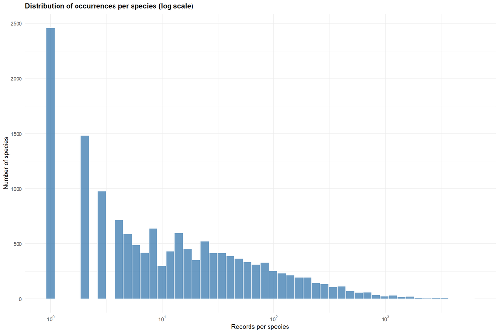

```r
ggplot(sp_occurrences, aes(x = n_occ)) +
  geom_histogram(bins = 50, fill = "steelblue", color = "white", alpha = 0.8) +
  scale_x_log10(
    breaks = scales::trans_breaks("log10", function(x) 10^x),
    labels = scales::trans_format("log10", scales::math_format(10^.x))
  ) +
  labs(
    title = "Distribution of occurrences per species (log scale)",
    x = "Records per species",
    y = "Number of species"
  ) +
  theme_minimal(base_size = 11) +
  theme(
    plot.title = element_text(face = "bold", size = 12, margin = margin(b = 8))
  )
```

### Species rarity: rare species (<10 and <20 records)

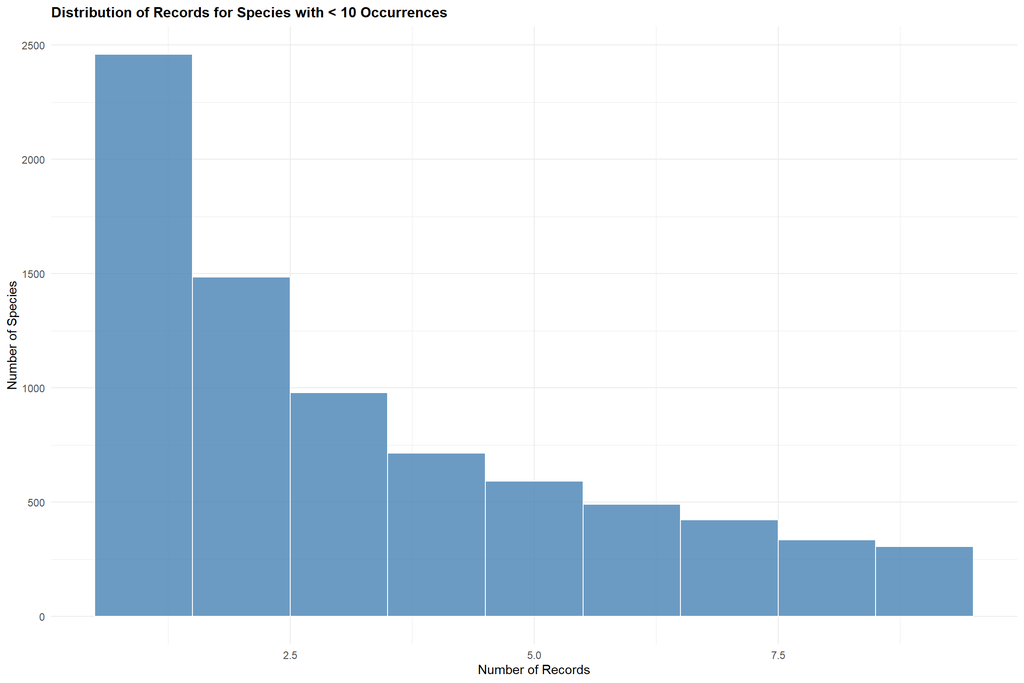

```r
# Calculate occurrences per species
sp_occurrences <- db %>%
  filter(!is.na(scientificName)) %>%
  group_by(scientificName) %>%
  summarise(n_records = n(), .groups = "drop")

# Species with < 10 records
sp_less_10 <- sp_occurrences %>%
  filter(n_records < 10)

# Species with < 20 records
sp_less_20 <- sp_occurrences %>%
  filter(n_records < 20)

# Histogram for species with < 10 records
p1 <- ggplot(sp_less_10, aes(x = n_records)) +
  geom_histogram(bins = 9, fill = "steelblue", color = "white", alpha = 0.8) +
  labs(
    title = "Distribution of Records for Species with < 10 Occurrences",
    x = "Number of Records",
    y = "Number of Species"
  ) +
  theme_minimal(base_size = 11) +
  theme(plot.title = element_text(face = "bold", size = 12))

# Histogram for species with < 20 records
p2 <- ggplot(sp_less_20, aes(x = n_records)) +
  geom_histogram(bins = 19, fill = "coral", color = "white", alpha = 0.8) +
  labs(
    title = "Distribution of Records for Species with < 20 Occurrences",
    x = "Number of Records",
    y = "Number of Species"
  ) +
  theme_minimal(base_size = 11) +
  theme(plot.title = element_text(face = "bold", size = 12))

# Display both plots
p1
```

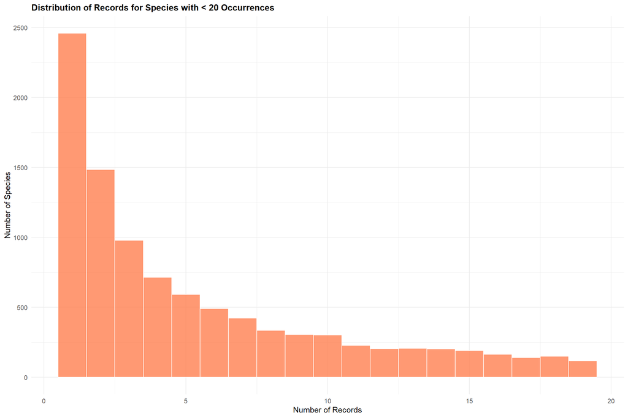

```r
p2
```

There are 7785 species with fewer than 10 records and 9694 species with fewer than 20 records in the dataset. This substantial pool of rare species is a key consideration for SDM development, as they require specialized approaches beyond standard modeling techniques.

```r
# Get detailed info for species with < 20 records
rare_species_detail <- db %>%
  filter(!is.na(scientificName), !is.na(family), !is.na(genus)) %>%
  group_by(family, genus, scientificName) %>%
  summarise(
    n_records_total = n(),
    n_r_occurrences = sum(dataset == "Occurrence data"),
    n_r_communities = sum(dataset == "Community data"),
    .groups = "drop"
  ) %>%
  filter(n_records_total < 20) %>%
  arrange(desc(n_records_total))

knitr::kable(rare_species_detail[c(1:10),],
             caption = "Species with < 20 records: Family, genus, species, and record counts by data type",
             col.names = c("Family", "Genus", "Species", "Total Records",
                           "Occurrences_source", "Communities_source"))
```

Species with < 20 records: Family, genus, species, and record counts by data type

| Family | Genus | Species | Total Records | Occurrences_source | Communities_source |
| --- | --- | --- | --- | --- | --- |
| Araceae | Anthurium | Anthurium armeniense | 19 | 19 | 0 |
| Araceae | Anthurium | Anthurium cerropelonense | 19 | 19 | 0 |
| Araceae | Anthurium | Anthurium holm-nielsenii | 19 | 19 | 0 |
| Araceae | Anthurium | Anthurium subcoerulescens | 19 | 19 | 0 |
| Araceae | Anthurium | Anthurium zeneidae | 19 | 19 | 0 |
| Araceae | Heteropsis | Heteropsis tenuispadix | 19 | 12 | 7 |
| Araceae | Monstera | Monstera epipremnoides | 19 | 19 | 0 |
| Araceae | Philodendron | Philodendron aureimarginatum | 19 | 19 | 0 |
| Araceae | Philodendron | Philodendron revillanum | 19 | 19 | 0 |
| Araceae | Syngonium | Syngonium hastifolium | 19 | 19 | 0 |

```r
dim(rare_species_detail)
```

```
[1] 9720    6
```

```r
# Count species with at least one community record
rare_species_detail %>%
   filter(n_r_communities > 0) %>%
   nrow()
```

```
[1] 652
```

```r
# Get detailed info for species with < 20 records
rare_species_detail1 <- db %>%
  filter(!is.na(scientificName), !is.na(family), !is.na(genus)) %>%
  group_by(family, genus, scientificName) %>%
  summarise(
    n_records_total = n(),
    n_r_occurrences = sum(dataset == "Occurrence data"),
    n_r_communities = sum(dataset == "Community data"),
    .groups = "drop"
  ) %>%
  filter(n_records_total < 10) %>%
  arrange(desc(n_records_total))

knitr::kable(rare_species_detail1[c(1:10),],
             caption = "Species with < 10 records: Family, genus, species, and record counts by data type",
             col.names = c("Family", "Genus", "Species", "Total Records",
                           "Occurrences_source", "Communities_source"))
```

Species with < 10 records: Family, genus, species, and record counts by data type

| Family | Genus | Species | Total Records | Occurrences_source | Communities_source |
| --- | --- | --- | --- | --- | --- |
| Araceae | Anthurium | Anthurium bernardii | 9 | 9 | 0 |
| Araceae | Anthurium | Anthurium blanquitense | 9 | 9 | 0 |
| Araceae | Anthurium | Anthurium brevipes | 9 | 9 | 0 |
| Araceae | Anthurium | Anthurium cabrerense | 9 | 9 | 0 |
| Araceae | Anthurium | Anthurium debilis | 9 | 9 | 0 |
| Araceae | Anthurium | Anthurium hoehnei | 9 | 9 | 0 |
| Araceae | Anthurium | Anthurium lakei | 9 | 9 | 0 |
| Araceae | Anthurium | Anthurium mikeneei | 9 | 9 | 0 |
| Araceae | Anthurium | Anthurium molle | 9 | 9 | 0 |
| Araceae | Anthurium | Anthurium nubicola | 9 | 9 | 0 |

```r
dim(rare_species_detail1)
```

```
[1] 7811    6
```

```r
# Count species with at least one community record
rare_species_detail1 %>%
   filter(n_r_communities > 0) %>%
   nrow()
```

```
[1] 405
```

## Geographic coverage

### Occurrence point distribution

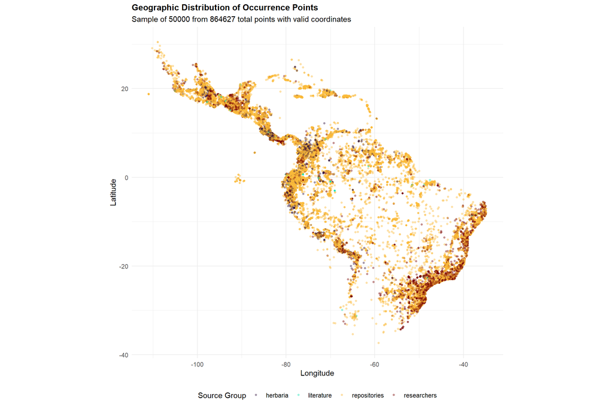

```r
db_coords <- db %>%
  filter(!is.na(decimalLatitude) & !is.na(decimalLongitude)) %>%
  filter(decimalLatitude >= -90 & decimalLatitude <= 90,
         decimalLongitude >= -180 & decimalLongitude <= 180)

# Sample for visualization
set.seed(4821)
db_sample <- db_coords %>% slice_sample(n = min(50000, nrow(db_coords)))

ggplot(db_sample, aes(x = decimalLongitude, y = decimalLatitude, color = source_group)) +
  geom_point(size = 1, alpha = 0.4) +
  coord_fixed() +
  scale_color_viridis_d(option = "turbo", name = "Source Group") +
  theme_minimal() +
  labs(title = "Geographic Distribution of Occurrence Points",
       subtitle = sprintf("Sample of %d from %d total points with valid coordinates",
                          nrow(db_sample), nrow(db_coords)),
       x = "Longitude", y = "Latitude") +
  theme(legend.position = "bottom",
        plot.title = element_text(face = "bold", size = 12))
```

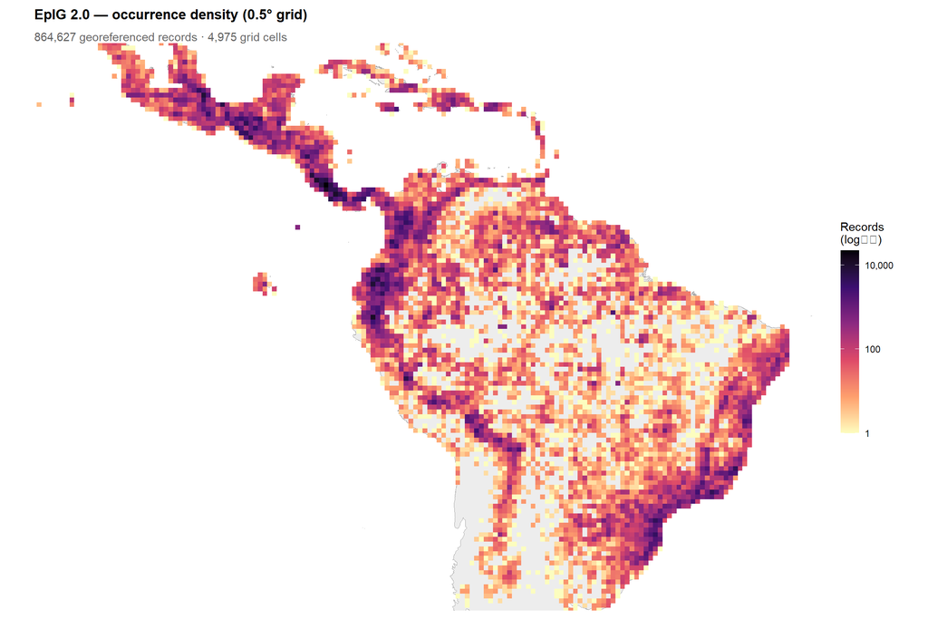

```r
# Aggregate records into 0.5° grid cells for fast rendering
grid_counts <- db |>
  filter(!is.na(decimalLatitude), !is.na(decimalLongitude)) |>
  mutate(
    lon_bin = round(decimalLongitude / 0.5) * 0.5,
    lat_bin = round(decimalLatitude  / 0.5) * 0.5
  ) |>
  count(lon_bin, lat_bin)

nt <- st_read("../layers/Neotropics_Morrone/Neotropic_dissolved.shp")
nt_simple <- st_simplify(nt, dTolerance = 0.05)

ggplot() +
  geom_sf(data = nt_simple, fill = "grey93", colour = "grey65", linewidth = 0.2) +
  geom_tile(
    data = grid_counts,
    aes(x = lon_bin, y = lat_bin, fill = n),
    width = 0.5, height = 0.5
  ) +
  scale_fill_viridis_c(
    option    = "magma",
    direction = -1,
    trans     = "log10",
    labels    = scales::comma,
    name      = "Records\n(log\u2081\u2080)"
  ) +
  coord_sf(xlim = c(-115, -30), ylim = c(-35, 25), expand = FALSE) +
  labs(
    title    = "EpIG 2.0 \u2014 occurrence density (0.5\u00b0 grid)",
    subtitle = paste0(
      format(sum(grid_counts$n), big.mark = ","),
      " georeferenced records \u00b7 ",
      format(nrow(grid_counts), big.mark = ","), " grid cells"
    ),
    x = NULL, y = NULL
  ) +
  theme_void(base_size = 11) +
  theme(
    plot.title        = element_text(face = "bold", margin = margin(b = 4)),
    plot.subtitle     = element_text(colour = "grey40"),
    legend.position   = "right",
    legend.key.height = unit(1.2, "cm"),
    plot.margin       = margin(8, 8, 8, 8)
  )
```

### Species Richness Grid

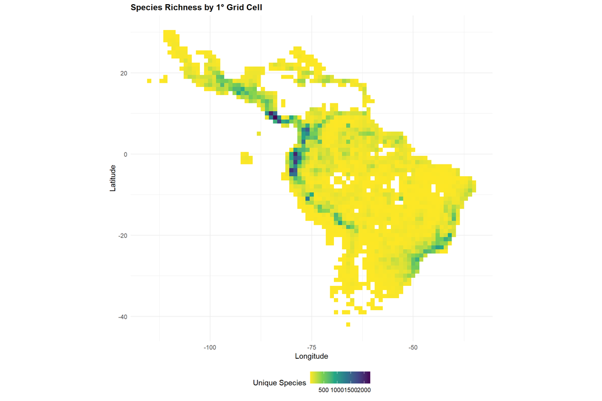

```r
richness_grid <- db_coords %>%
  filter(!is.na(scientificName)) %>%
  mutate(
    lat_cell = floor(decimalLatitude),
    lon_cell = floor(decimalLongitude)
  ) %>%
  group_by(lat_cell, lon_cell) %>%
  summarise(
    n_species = n_distinct(scientificName),
    n_records = n(),
    .groups = "drop"
  ) %>%
  filter(!is.na(lat_cell) & !is.na(lon_cell))

ggplot(richness_grid, aes(x = lon_cell, y = lat_cell, fill = n_species)) +
  geom_tile() +
  coord_fixed() +
  scale_fill_viridis_c(option = "viridis", direction = -1, name = "Unique Species") +
  theme_minimal() +
  labs(title = "Species Richness by 1° Grid Cell",
       x = "Longitude", y = "Latitude") +
  theme(plot.title = element_text(face = "bold", size = 12),
        legend.position = "bottom")
```

```r
richness_summary <- richness_grid %>%
  summarise(
    Mean_Species_per_Cell = round(mean(n_species), 1),
    Max_Species_in_Cell = max(n_species),
    Median_Species_per_Cell = median(n_species),
    Total_Grid_Cells = n()
  )

knitr::kable(richness_summary, caption = "Species Richness Summary Statistics")
```

Species Richness Summary Statistics

| Mean_Species_per_Cell | Max_Species_in_Cell | Median_Species_per_Cell | Total_Grid_Cells |
| --- | --- | --- | --- |
| 115.2 | 2227 | 31 | 1656 |

## Sampling bias

```r
# Prepare data for sampbias
# Important: sampbias needs a species column, not only coordinates
db_coords_sb <- db %>%
  filter(
    !is.na(decimalLatitude),
    !is.na(decimalLongitude),
    decimalLatitude >= -90,
    decimalLatitude <= 90,
    decimalLongitude >= -180,
    decimalLongitude <= 180,
    !is.na(scientificName),
    scientificName != ""
  ) %>%
  transmute(
    species = scientificName,
    decimalLongitude = as.numeric(decimalLongitude),
    decimalLatitude  = as.numeric(decimalLatitude)
  )

# Calculate sampling bias
sampbias_result <- calculate_bias(
  x = db_coords_sb,
  res = 2,
  terrestrial = TRUE
)

# See summary
summary(sampbias_result)
```

```
Number of occurences:  864627
Raster resolution:  2
Convexhull:
Geographic extent:
SpatExtent : -115, -35, -42, 32 (xmin, xmax, ymin, ymax)
Bias weights:
               bias_weight      std_dev
w_roads       4.887587e-03 3.725234e-05
w_cities      1.256917e-07 4.891609e-08
w_waterbodies 7.112674e-03 2.250880e-05
w_airports    3.270806e-03 8.783535e-06
hp_rate       3.060460e+02 1.406311e+02
```

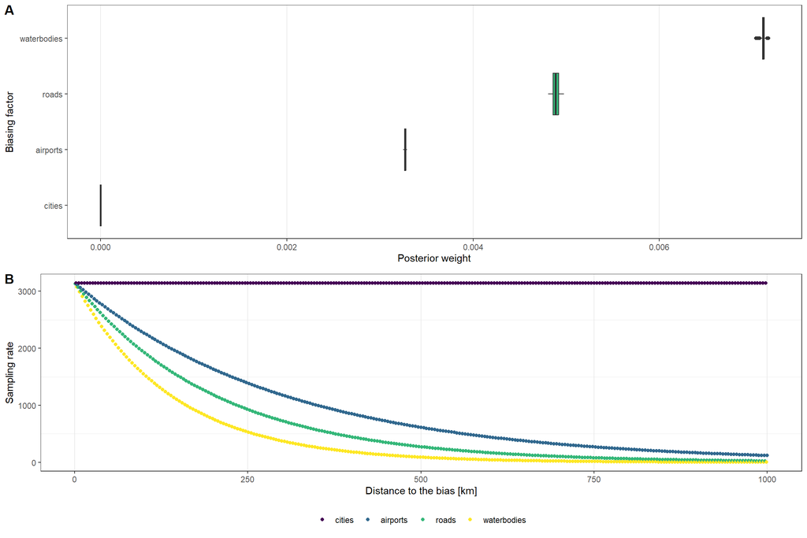

```r
# Plot posterior estimates of bias weights
plot(sampbias_result)
```

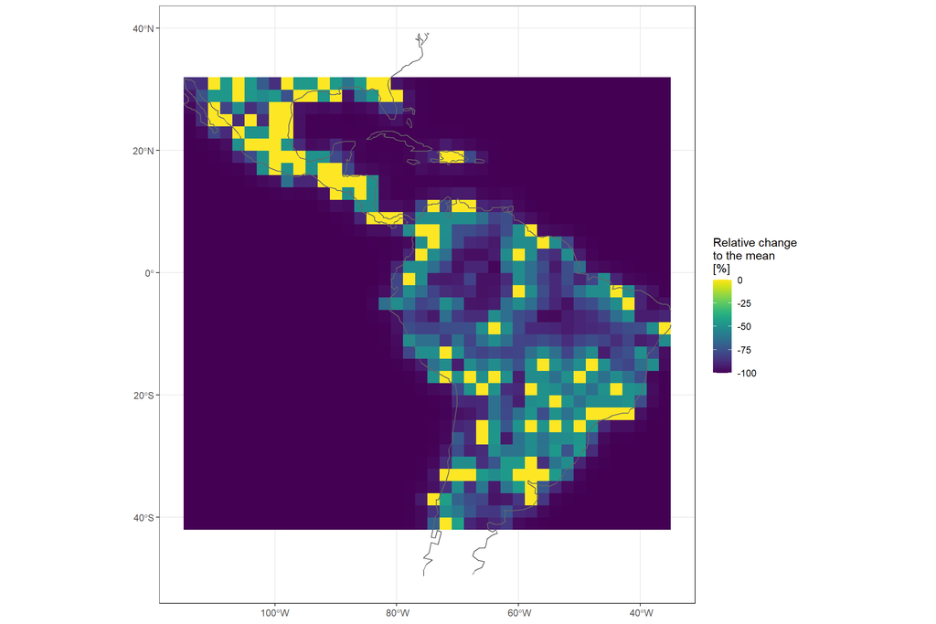

```r
# 4. Proyectar el sesgo al espacio
sampbias_map <- project_bias(sampbias_result)

# 5. Mapa del sesgo en escala log10
map_bias(
  sampbias_map,
  type = "diff_to_max"
)
```

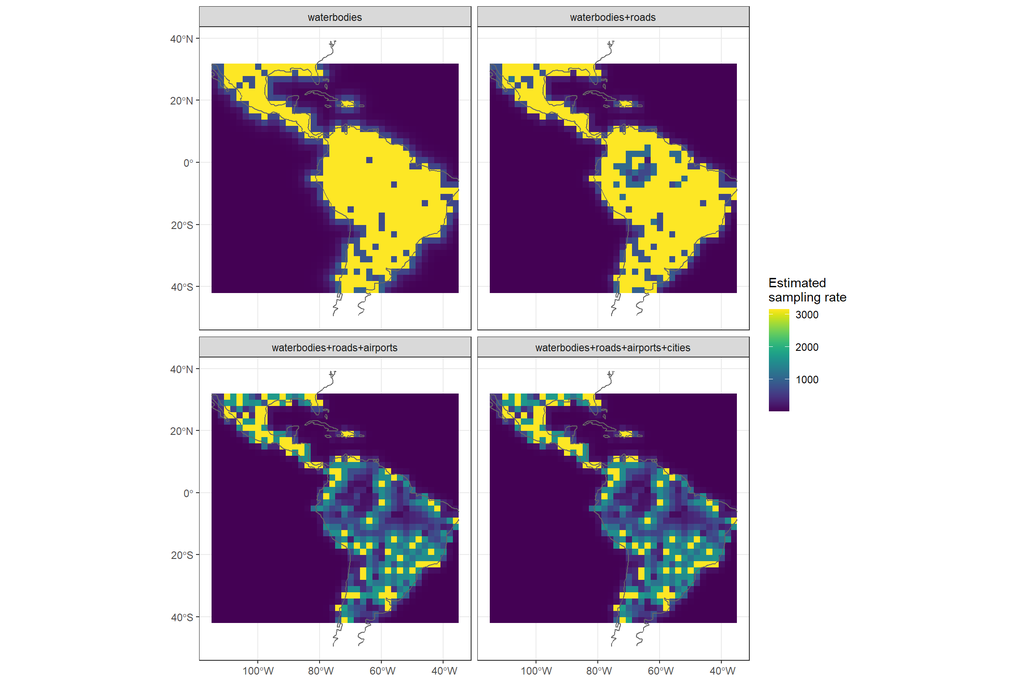

```r
map_bias(
  sampbias_map,
  type = "sampling_rate"
)
```

## Family concentration

```r
# Calculate species concentration across families
family_species <- db %>%
  filter(!is.na(family), !is.na(scientificName)) %>%
  group_by(family) %>%
  summarise(n_species = n_distinct(scientificName), .groups = "drop") %>%
  arrange(desc(n_species))

# Total families and total species
total_families <- nrow(family_species)
total_species_all <- sum(family_species$n_species)

# Top 6 families
top_10_families <- family_species %>%
  head(10) %>%
  mutate(pct_of_total = round(100 * n_species / total_species_all, 2))

# Concentration in top 6
concentration_top_10 <- round(100 * sum(top_10_families$n_species) / total_species_all, 1)

# Create summary text with inline values
species_top_10_table <- top_10_families %>%
  rename(Family = family, Species = n_species, `% of Total` = pct_of_total) %>%
  select(Family, Species, `% of Total`)

knitr::kable(species_top_10_table, caption = "Top 10 Families by Species Count")
```

Top 10 Families by Species Count

| Family | Species | % of Total |
| --- | --- | --- |
| Orchidaceae | 7643 | 51.00 |
| Bromeliaceae | 1860 | 12.41 |
| Araceae | 1527 | 10.19 |
| Polypodiaceae | 658 | 4.39 |
| Piperaceae | 488 | 3.26 |
| Dryopteridaceae | 411 | 2.74 |
| Ericaceae | 327 | 2.18 |
| Gesneriaceae | 282 | 1.88 |
| Melastomataceae | 242 | 1.61 |
| Hymenophyllaceae | 191 | 1.27 |

In this dataset, 90.9% of all epiphyte species are concentrated in just the top 10 families. There are 65 families total, but species diversity is heavily skewed: the top family has 7643 species, while the top 10 families account for 13629 species combined.

### Top Families

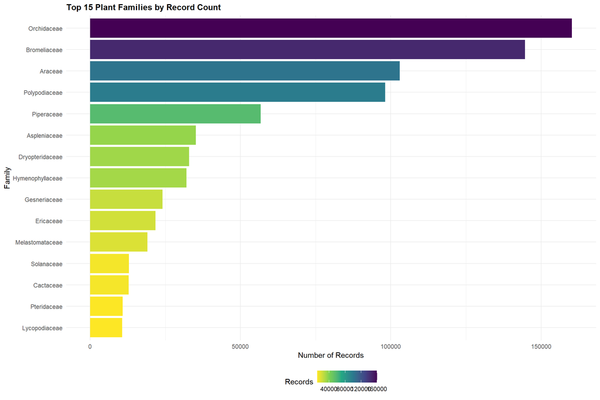

```r
family_counts <- db %>%
  filter(!is.na(family)) %>%
  count(family) %>%
  arrange(desc(n)) %>%
  head(15) %>%
  mutate(pct = round(100 * n / sum(n), 1))

ggplot(family_counts, aes(x = reorder(family, n), y = n, fill = n)) +
  geom_col() +
  coord_flip() +
  scale_fill_viridis_c(direction = -1, option = "viridis") +
  theme_minimal() +
  labs(title = "Top 15 Plant Families by Record Count",
       x = "Family", y = "Number of Records", fill = "Records") +
  theme(plot.title = element_text(face = "bold", size = 12),
        legend.position = "bottom")
```

```r
family_richness <- db %>%
  filter(!is.na(family), !is.na(genus), !is.na(scientificName)) %>%
  group_by(family) %>%
  summarise(
    Records = n(),
    Genus = n_distinct(genus),
    Species = n_distinct(scientificName),
    .groups = "drop"
  ) %>%
  arrange(desc(Records)) %>%
  head(15)

knitr::kable(family_richness, caption = "Top 15 Families: Records and Species Count")
```

Top 15 Families: Records and Species Count

| family | Records | Genus | Species |
| --- | --- | --- | --- |
| Orchidaceae | 160294 | 290 | 7643 |
| Bromeliaceae | 144685 | 49 | 1860 |
| Araceae | 103003 | 12 | 1527 |
| Polypodiaceae | 98118 | 38 | 658 |
| Piperaceae | 56706 | 2 | 488 |
| Aspleniaceae | 35189 | 2 | 141 |
| Dryopteridaceae | 32895 | 17 | 411 |
| Hymenophyllaceae | 32021 | 5 | 191 |
| Gesneriaceae | 24094 | 22 | 282 |
| Ericaceae | 21717 | 27 | 327 |
| Melastomataceae | 19094 | 13 | 242 |
| Solanaceae | 12888 | 11 | 53 |
| Cactaceae | 12786 | 17 | 128 |
| Pteridaceae | 10861 | 14 | 45 |
| Lycopodiaceae | 10665 | 3 | 84 |

### Top Genera

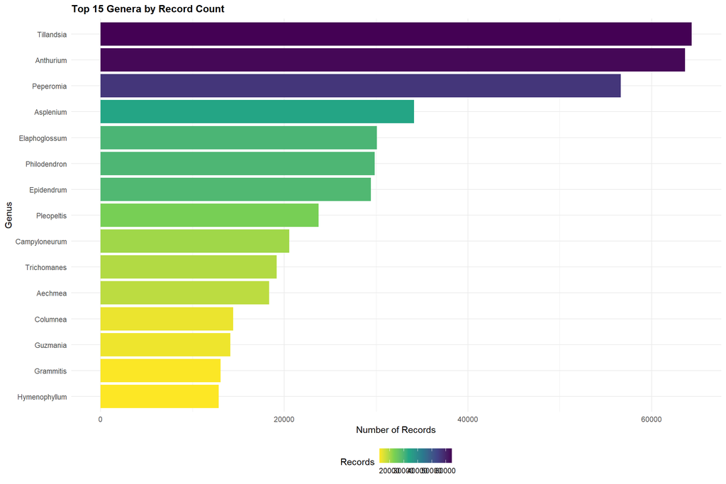

```r
genus_counts <- db %>%
  filter(!is.na(genus)) %>%
  count(genus) %>%
  arrange(desc(n)) %>%
  head(15)

ggplot(genus_counts, aes(x = reorder(genus, n), y = n, fill = n)) +
  geom_col() +
  coord_flip() +
  scale_fill_viridis_c(direction = -1, option = "viridis") +
  theme_minimal() +
  labs(title = "Top 15 Genera by Record Count",
       x = "Genus", y = "Number of Records", fill = "Records") +
  theme(plot.title = element_text(face = "bold", size = 12),
        legend.position = "bottom")
```

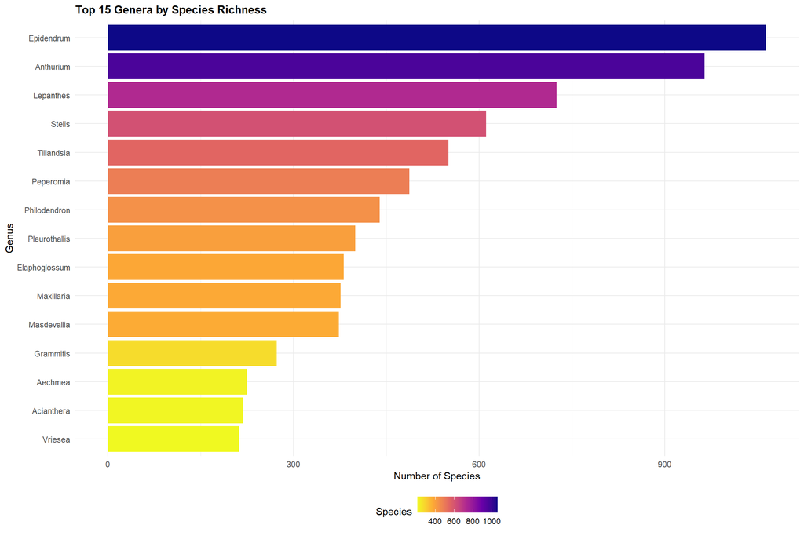

```r
genus_richness <- db %>%
  filter(!is.na(genus), !is.na(scientificName)) %>%
  group_by(genus) %>%
  summarise(n_species = n_distinct(scientificName), .groups = "drop") %>%
  arrange(desc(n_species)) %>%
  head(15)

ggplot(genus_richness, aes(x = reorder(genus, n_species), y = n_species, fill = n_species)) +
  geom_col() +
  coord_flip() +
  scale_fill_viridis_c(direction = -1, option = "plasma") +
  theme_minimal() +
  labs(title = "Top 15 Genera by Species Richness",
       x = "Genus", y = "Number of Species", fill = "Species") +
  theme(plot.title = element_text(face = "bold", size = 12),
        legend.position = "bottom")
```

```r
# Combine records and species counts for top genera
genus_combined <- db %>%
  filter(!is.na(genus), !is.na(scientificName)) %>%
  group_by(genus) %>%
  summarise(
    Records = n(),
    Species = n_distinct(scientificName),
    .groups = "drop"
  ) %>%
  arrange(desc(Species)) %>%
  head(15)

knitr::kable(genus_combined, caption = "Top 15 Genera: Records and Species Count")
```

Top 15 Genera: Records and Species Count

| genus | Records | Species |
| --- | --- | --- |
| Epidendrum | 29444 | 1063 |
| Anthurium | 63633 | 964 |
| Lepanthes | 5157 | 725 |
| Stelis | 5668 | 611 |
| Tillandsia | 64367 | 550 |
| Peperomia | 56635 | 487 |
| Philodendron | 29830 | 439 |
| Pleurothallis | 8257 | 400 |
| Elaphoglossum | 30082 | 381 |
| Maxillaria | 7141 | 376 |
| Masdevallia | 3335 | 373 |
| Grammitis | 13048 | 273 |
| Aechmea | 18339 | 225 |
| Acianthera | 5003 | 219 |
| Vriesea | 10664 | 212 |

### Geographic distribution of top genera

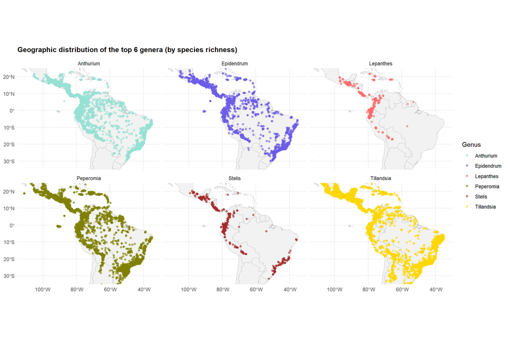

```r
# Get top 6 genera by species richness
top_6_genera <- db %>%
  filter(!is.na(genus), !is.na(scientificName)) %>%
  group_by(genus) %>%
  summarise(n_species = n_distinct(scientificName), .groups = "drop") %>%
  arrange(desc(n_species)) %>%
  head(6) %>%
  pull(genus)

# Filter data for top 6 genera with valid coordinates
map_top_genera <- db %>%
  filter(genus %in% top_6_genera) %>%
  filter(!is.na(decimalLatitude), !is.na(decimalLongitude)) %>%
  filter(decimalLatitude >= -90 & decimalLatitude <= 90,
         decimalLongitude >= -180 & decimalLongitude <= 180)

# Sample for cleaner visualization if needed
set.seed(8374)
map_top_genera_plot <- map_top_genera %>%
  slice_sample(n = min(25000, nrow(map_top_genera)))

# Get world map
world_map <- ne_countries(scale = "medium", returnclass = "sf")

# Create map with Tillandsia assigned the brightest color
genus_colors <- c(
  "Tillandsia" = "#FFD700",    # Bright gold/yellow (clearest)
  "Lepanthes" = "#FF6B6B",   # Coral red
  "Stelis" = "#A52A2A",      # Teal
  "Anthurium" = "#95E1D3",       # Light mint
  "Epidendrum" = "#6C5CE7",        # Purple
  "Peperomia" = "#808000"     # Olive
)

ggplot() +
  geom_sf(data = world_map, fill = "grey95", color = "grey70", linewidth = 0.3) +
  geom_point(
    data = map_top_genera_plot,
    aes(x = decimalLongitude, y = decimalLatitude, color = genus),
    size = 1.5, alpha = 0.6
  ) +
  facet_wrap(~genus) +
  scale_color_manual(values = genus_colors, name = "Genus") +
  coord_sf(xlim = c(-115, -30), ylim = c(-35, 25), expand = FALSE) +
  labs(
    title = "Geographic distribution of the top 6 genera (by species richness)",
    x = NULL, y = NULL
  ) +
  theme_minimal(base_size = 11) +
  theme(
    plot.title = element_text(face = "bold", size = 12, margin = margin(b = 8)),
    legend.position = "right"
  )
```

```r
# Get lower 6 genera by species richness
top_6_genera <- db %>%
  filter(!is.na(genus), !is.na(scientificName)) %>%
  group_by(genus) %>%
  summarise(n_species = n_distinct(scientificName), .groups = "drop") %>%
  arrange(desc(n_species)) %>%
  head(6) %>%
  pull(genus)
```

## Temporal distribution

### Collection Effort Over Time

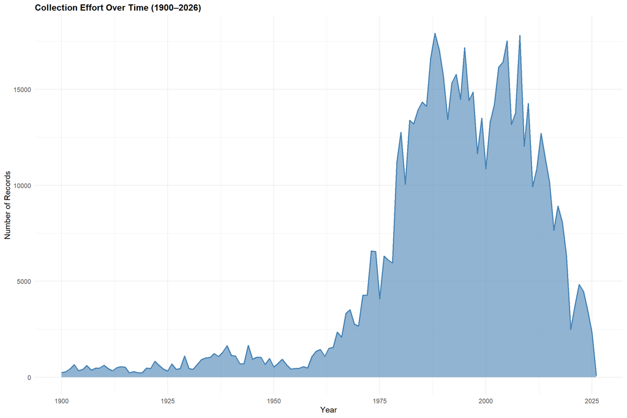

```r
timeline <- db %>%
  filter(!is.na(year)) %>%
  mutate(year = as.numeric(year)) %>%
  filter(year >= 1900 & year <= 2026) %>%
  count(year) %>%
  arrange(year)

ggplot(timeline, aes(x = year, y = n)) +
  geom_area(fill = "steelblue", alpha = 0.6) +
  geom_line(color = "steelblue", size = 0.8) +
  theme_minimal() +
  labs(title = "Collection Effort Over Time (1900–2026)",
       x = "Year", y = "Number of Records") +
  theme(plot.title = element_text(face = "bold", size = 12)) +
  scale_x_continuous(breaks = seq(1900, 2026, 25))
```

```r
# Summary statistics
year_summary <- db %>%
  filter(!is.na(year)) %>%
  mutate(year = as.numeric(year)) %>%
  summarise(
    Records_Pre_1980 = sum(year < 1980),
    Records_1980_2000 = sum(year >= 1980 & year < 2000),
    Records_2000_2020 = sum(year >= 2000 & year < 2020),
    Records_Post_2020 = sum(year >= 2020)
  ) %>%
  pivot_longer(everything(), names_to = "Period", values_to = "Records")

knitr::kable(year_summary, caption = "Records by Decade")
```

Records by Decade

| Period | Records |
| --- | --- |
| Records_Pre_1980 | 125015 |
| Records_1980_2000 | 289556 |
| Records_2000_2020 | 245429 |
| Records_Post_2020 | 21476 |

# Pilot

```r
# Species rarity distribution
species_rarity <- db %>%
  group_by(scientificName) %>%
  summarise(n_records = n(), .groups = 'drop') %>%
  mutate(
    record_class = case_when(
      n_records == 1 ~ "1 record",
      n_records < 5 ~ "2-4 records",
      n_records < 10 ~ "5-9 records",
      n_records < 20 ~ "10-19 records",
      n_records < 30 ~ "20-29 records",
      n_records < 50 ~ "30-49 records",
      n_records < 100 ~ "50-99 records",
      TRUE ~ "100+ records"
    )
  ) %>%
  count(record_class) %>%
  rename(`Record Class` = record_class, `Number of Species` = n) %>%
  mutate(`Record Class` = factor(`Record Class`,
    levels = c("1 record", "2-4 records", "5-9 records", "10-19 records",
               "20-29 records", "30-49 records", "50-99 records", "100+ records"))) %>%
  arrange(`Record Class`)

knitr::kable(species_rarity, caption = "Distribution of Species by Number of Records")
```

Distribution of Species by Number of Records

| Record Class | Number of Species |
| --- | --- |
| 1 record | 2460 |
| 2-4 records | 3179 |
| 5-9 records | 2146 |
| 10-19 records | 1909 |
| 20-29 records | 1000 |
| 30-49 records | 1219 |
| 50-99 records | 1255 |
| 100+ records | 1813 |

```r
# Genus rarity distribution
genus_rarity <- db %>%
  group_by(genus) %>%
  summarise(n_records = n(), .groups = 'drop') %>%
  mutate(
    record_class = case_when(
      n_records == 1 ~ "1 record",
      n_records < 5 ~ "2-4 records",
      n_records < 10 ~ "5-9 records",
      n_records < 20 ~ "10-19 records",
      n_records < 30 ~ "20-29 records",
      n_records < 50 ~ "30-49 records",
      n_records < 100 ~ "50-99 records",
      TRUE ~ "100+ records"
    )
  ) %>%
  count(record_class) %>%
  rename(`Record Class` = record_class, `Number of Genera` = n) %>%
  mutate(`Record Class` = factor(`Record Class`,
    levels = c("1 record", "2-4 records", "5-9 records", "10-19 records",
               "20-29 records", "30-49 records", "50-99 records", "100+ records"))) %>%
  arrange(`Record Class`)

knitr::kable(genus_rarity, caption = "Distribution of Genera by Number of Records")
```

Distribution of Genera by Number of Records

| Record Class | Number of Genera |
| --- | --- |
| 1 record | 42 |
| 2-4 records | 55 |
| 5-9 records | 41 |
| 10-19 records | 47 |
| 20-29 records | 26 |
| 30-49 records | 41 |
| 50-99 records | 73 |
| 100+ records | 319 |

```r
# Filter species with >= 5 records
species_5plus <- db %>%
  group_by(scientificName) %>%
  filter(n() >= 5) %>%
  ungroup()

# Count remaining species and families
species_count_filtered <- species_5plus %>%
  pull(scientificName) %>%
  n_distinct()

family_count_filtered <- species_5plus %>%
  pull(family) %>%
  n_distinct()

records_filtered <- nrow(species_5plus)

summary_after_filter <- tibble(
  Metric = c("Number of Records", "Number of Species", "Number of Families"),
  Count = c(records_filtered, species_count_filtered, family_count_filtered)
)

knitr::kable(summary_after_filter, caption = "Summary After Removing Species with < 5 Records")
```

Summary After Removing Species with < 5 Records

| Metric | Count |
| --- | --- |
| Number of Records | 853400 |
| Number of Species | 9342 |
| Number of Families | 62 |

## GENUS LEVEL APPROACH: pilot genus: Epidendrum and Andinia

Andinia has 27 species Bulbophyllum 71 Epidendrum 1063

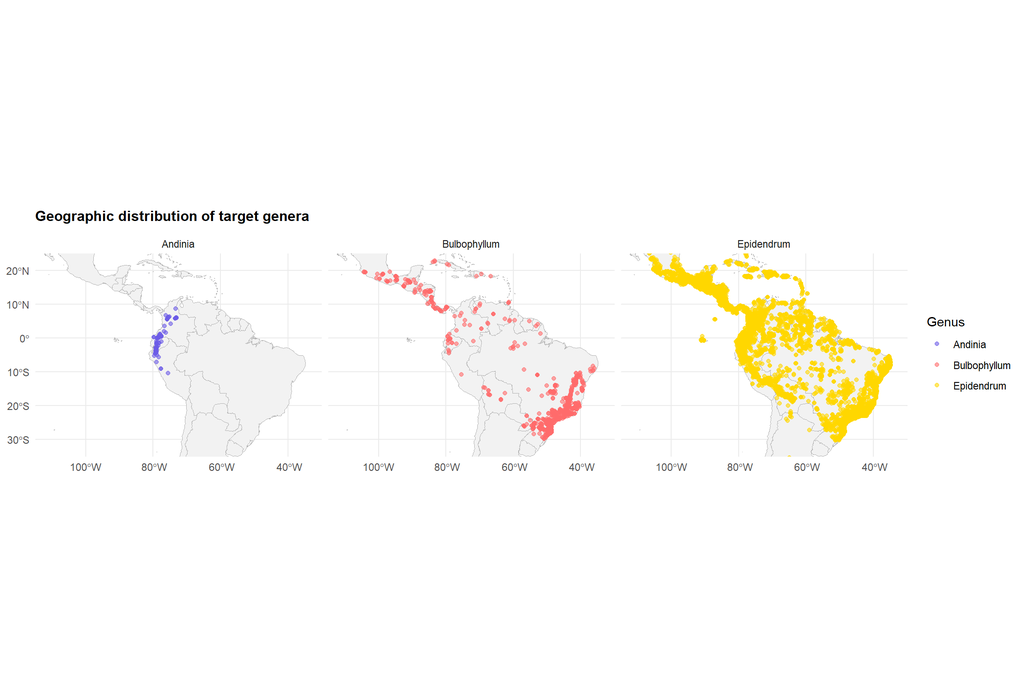

```r
# Genus restricted to the Andes, widespread, widespread+diverse
target <- c("Andinia", "Bulbophyllum", "Epidendrum")

# Filter data for top 6 genera with valid coordinates
map_target_genera <- db %>%
  filter(genus %in% target) %>%
  filter(!is.na(decimalLatitude), !is.na(decimalLongitude)) %>%
  filter(decimalLatitude >= -90 & decimalLatitude <= 90,
         decimalLongitude >= -180 & decimalLongitude <= 180)

# Sample for cleaner visualization if needed
set.seed(8374)
map_target_genera <- map_target_genera %>%
  slice_sample(n = min(25000, nrow(map_target_genera)))

# Get world map
world_map <- ne_countries(scale = "medium", returnclass = "sf")

# Create map with Tillandsia assigned the brightest color
genus_colors <- c(
  "Epidendrum" = "#FFD700",    # Bright gold/yellow (clearest)
  "Bulbophyllum" = "#FF6B6B",   # Coral red
  "Andinia" = "#6C5CE7"        # Purple
)

ggplot() +
  geom_sf(data = world_map, fill = "grey95", color = "grey70", linewidth = 0.3) +
  geom_point(
    data = map_target_genera,
    aes(x = decimalLongitude, y = decimalLatitude, color = genus),
    size = 1.5, alpha = 0.6
  ) +
  facet_wrap(~genus) +
  scale_color_manual(values = genus_colors, name = "Genus") +
  coord_sf(xlim = c(-115, -30), ylim = c(-35, 25), expand = FALSE) +
  labs(
    title = "Geographic distribution of target genera",
    x = NULL, y = NULL
  ) +
  theme_minimal(base_size = 11) +
  theme(
    plot.title = element_text(face = "bold", size = 12, margin = margin(b = 8)),
    legend.position = "right"
  )
```

```r
db_genus_sf <- db %>%
  filter(genus == target)

genus_summary <- db_genus_sf %>%
  group_by(genus) %>%
  summarise(
    Records = n(),
    Species = n_distinct(scientificName),
    .groups = "drop"
  ) %>%
  arrange(desc(Records))

# Rarity structure
species_occurrences_ <- db_genus_sf %>%
  group_by(genus, scientificName) %>%
  summarise(n_occ = n(), .groups = "drop")

rarity_bins <- species_occurrences_ %>%
  mutate(
    bin = case_when(
      n_occ < 10 ~ "<10",
      n_occ >= 10 & n_occ < 50 ~ "10-50",
      n_occ >= 50 & n_occ < 100 ~ "50-100",
      n_occ >= 100 ~ ">100"
    )
  ) %>%
  count(bin) %>%
  mutate(bin = factor(bin, levels = c("<10", "10-50", "50-100", ">100"))) %>%
  arrange(bin)

# Extract values for inline text
rarity_rare <- rarity_bins %>% filter(bin == "<10") %>% pull(n)
rarity_common <- rarity_bins %>% filter(bin == ">100") %>% pull(n)
rarity_total <- sum(rarity_bins$n)

rarity_bins_table <- rarity_bins %>%
  rename("Occurrences per species" = bin, "Number of species" = n)

knitr::kable(rarity_bins_table, caption = "Distribution of species by occurrence count")
```

Distribution of species by occurrence count

| Occurrences per species | Number of species |
| --- | --- |
| <10 | 721 |
| 10-50 | 182 |
| 50-100 | 28 |
| >100 | 11 |

## SPECIES LEVEL APPROACH: pilot family: Bromeliaceae

Bromeliaceae is the second-largest plant family in this vascular epiphyte dataset, representing 144,685 records (16.7%) and 1860 species (12.4% of all species). The family is near-exclusively distributed across the **Neotropics**, spanning the full geographic extent of the study region from Mexico to southern Brazil.

Within the epiphyte-only context of this dataset, Bromeliaceae is structured around two main subfamilies with distinctly different ecological strategies. Tillandsioideae, the atmospheric epiphytes, account for 69,729 records across 623 species and occupy the broadest altitudinal and climatic range. Bromelioideae, the tank epiphytes, comprise 35,770 records and 563 species, with stronger preference for humid forest habitats.

The family also exhibits the same rarity structure as the full dataset: a heavy-tailed distribution with a few dominant species and many rare ones. Among Bromeliaceae species, 825 have fewer than 10 occurrences, while only 296 have over 100 records. The variation creates a natural test case for a bifurcated modeling approach: developing specialized methods for common species (where sufficient data exists for standard maximum entropy modeling) and rare species (where simpler or data-borrowing approaches may be needed).

The strong phylogenetic structure within Bromeliaceae—two well-defined subfamilies with clear ecological associations—also allows us to test whether modeling coherence and prediction quality improve when conditioning on higher taxonomic levels.

```r
# Dataset comparison
comparison <- tibble(
  Group = c("Full Dataset", "Bromeliaceae"),
  Records = c(total_records, brom_records),
  Species = c(total_species, brom_species),
  `Records (%)` = c(100, round(100 * brom_records / total_records, 1)),
  `Species (%)` = c(100, round(100 * brom_species / total_species, 1))
)

knitr::kable(comparison, caption = "Bromeliaceae contribution to the full dataset")
```

Bromeliaceae contribution to the full dataset

| Group | Records | Species | Records (%) | Species (%) |
| --- | --- | --- | --- | --- |
| Full Dataset | 864627 | 14981 | 100.0 | 100.0 |
| Bromeliaceae | 144685 | 1860 | 16.7 | 12.4 |

### Subfamily composition

```r
subfamily_summary <- db_brom_sf %>%
  filter(!is.na(subfamily) & subfamily != "Unknown") %>%
  group_by(subfamily) %>%
  summarise(
    Records = n(),
    Species = n_distinct(scientificName),
    Genera = n_distinct(genus),
    .groups = "drop"
  ) %>%
  arrange(desc(Records))

knitr::kable(subfamily_summary, caption = "Records, species, and genera per Bromeliaceae subfamily")
```

Records, species, and genera per Bromeliaceae subfamily

| subfamily | Records | Species | Genera |
| --- | --- | --- | --- |
| Tillandsioideae | 69729 | 623 | 4 |
| Bromelioideae | 35770 | 563 | 6 |

### Rarity structure

```r
rarity_bins_table <- rarity_bins %>%
  rename("Occurrences per species" = bin, "Number of species" = n)

knitr::kable(rarity_bins_table, caption = "Distribution of species by occurrence count")
```

Distribution of species by occurrence count

| Occurrences per species | Number of species |
| --- | --- |
| <10 | 825 |
| 10-50 | 543 |
| 50-100 | 196 |
| >100 | 296 |

Among Bromeliaceae species, rare species (fewer than 10 records) dominate numerically: 825 out of 1860 species. The tail of well-sampled species (>100 records) contains only 296 species, yet these represent a disproportionate fraction of the total records, illustrating the common-species-dominated sampling bias in occurrence data.

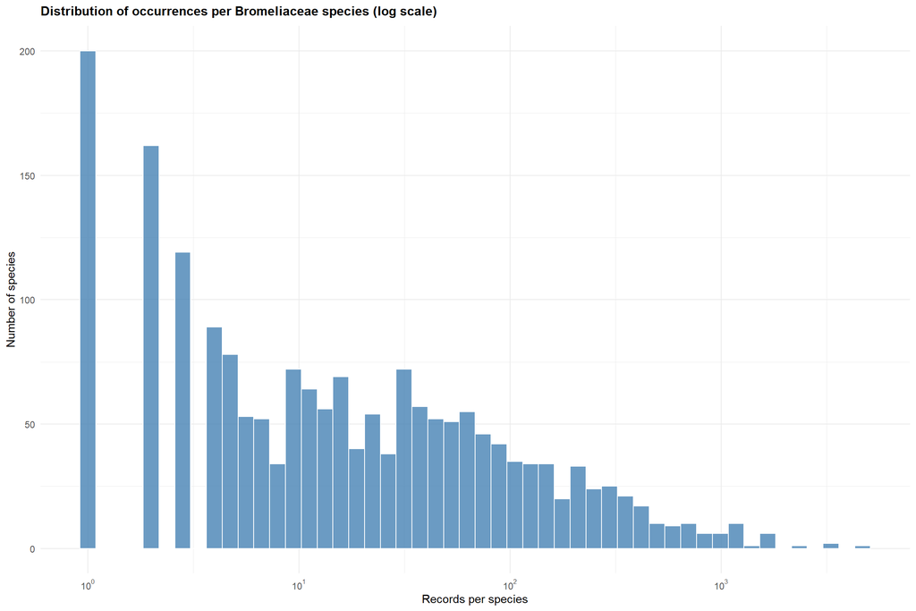

```r
ggplot(species_occurrences, aes(x = n_occ)) +
  geom_histogram(bins = 50, fill = "steelblue", color = "white", alpha = 0.8) +
  scale_x_log10(
    breaks = scales::trans_breaks("log10", function(x) 10^x),
    labels = scales::trans_format("log10", scales::math_format(10^.x))
  ) +
  labs(
    title = "Distribution of occurrences per Bromeliaceae species (log scale)",
    x = "Records per species",
    y = "Number of species"
  ) +
  theme_minimal(base_size = 11) +
  theme(
    plot.title = element_text(face = "bold", size = 12, margin = margin(b = 8))
  )
```

### Top genera

```r
top_genera <- db_brom_sf %>%
  filter(!is.na(genus)) %>%
  count(genus) %>%
  arrange(desc(n)) %>%
  head(10) %>%
  rename(Genus = genus, Records = n)

knitr::kable(top_genera, caption = "Top 10 genera in Bromeliaceae")
```

Top 10 genera in Bromeliaceae

| Genus | Records |
| --- | --- |
| Tillandsia | 64367 |
| Aechmea | 18339 |
| Guzmania | 14132 |
| Vriesea | 10664 |
| Werauhia | 5841 |
| Racinaea | 5347 |
| Catopsis | 5046 |
| Pitcairnia | 4478 |
| Billbergia | 3818 |
| Nidularium | 1613 |

The distribution is predictably skewed toward *Tillandsia* (64,367 records), but the next tier of genera—*Aechmea*, *Guzmania*, and *Vriesea*—provides sufficient sample sizes for independent model development and cross-validation.

### Geographic distribution

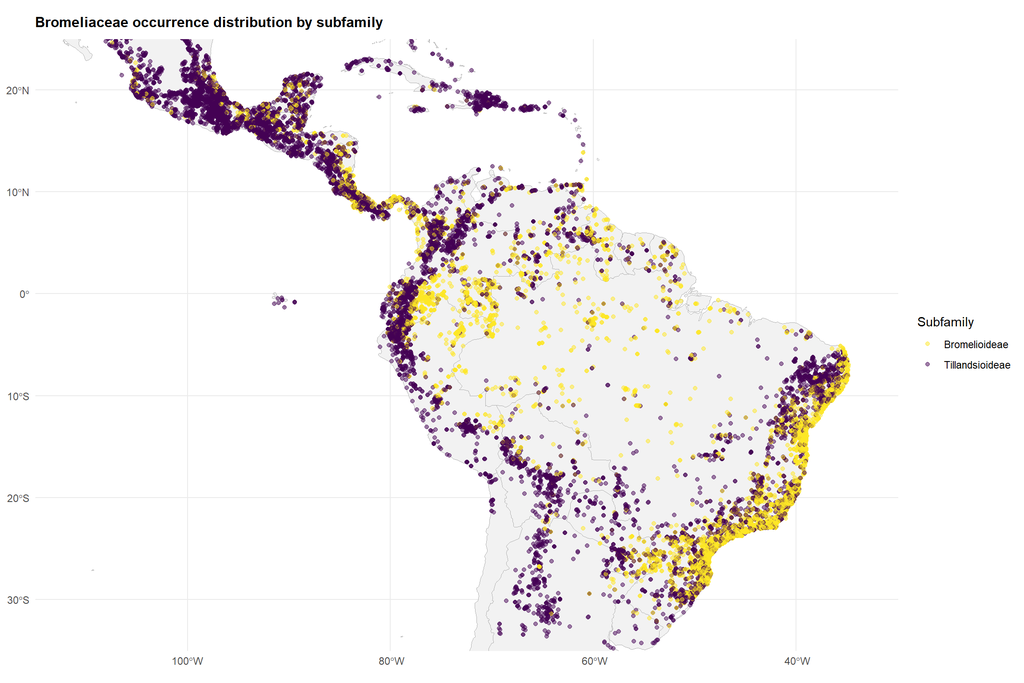

```r
library(rnaturalearth)
library(sf)

map_data <- db_brom_sf %>%
  filter(!is.na(decimalLatitude), !is.na(decimalLongitude),
         subfamily != "Unknown") %>%
  filter(decimalLatitude >= -90 & decimalLatitude <= 90,
         decimalLongitude >= -180 & decimalLongitude <= 180)

set.seed(7423)
map_data_plot <- map_data %>%
  slice_sample(n = min(30000, nrow(map_data)))

world <- ne_countries(scale = "medium", returnclass = "sf")

ggplot() +
  geom_sf(data = world, fill = "grey95", color = "grey70", linewidth = 0.3) +
  geom_point(
    data = map_data_plot,
    aes(x = decimalLongitude, y = decimalLatitude, color = subfamily),
    size = 1.5, alpha = 0.5
  ) +
  scale_color_manual(
    values = c("Tillandsioideae" = "#440154", "Bromelioideae" = "#FDE725"),
    name = "Subfamily"
  ) +
  coord_sf(xlim = c(-115, -30), ylim = c(-35, 25), expand = FALSE) +
  labs(
    title = "Bromeliaceae occurrence distribution by subfamily",
    x = NULL, y = NULL
  ) +
  theme_minimal(base_size = 11) +
  theme(
    plot.title = element_text(face = "bold", size = 12, margin = margin(b = 8)),
    legend.position = "right"
  )
```

The two subfamilies show clear geographic complementarity. Tillandsioideae (purple) dominates the northern and western regions, extending into Mexico and along the Andes, while Bromelioideae (yellow) is concentrated in the humid Atlantic forest regions of southeastern Brazil. This geographic structure, combined with their ecological differences, makes the subfamily distinction meaningful for modeling.

# Hotspots within the Neotropics

```r
library(sf)
library(dplyr)

# Load hotspots shapefile
hotspots <- st_read("../layers/hotspots_2016_1/hotspots_2016_1.shp", quiet = TRUE)
hotspots <- hotspots %>% filter(Type == "hotspot area")

# Load Neotropics boundary
neotropics <- st_read("../layers/Neotropics_Morrone/Neotropic_dissolved.shp", quiet = TRUE)

# Extract attributes without geometry (shapefile has topology issues)
hotspots_attrs <- st_drop_geometry(hotspots)

# Identify hotspots in Neotropics by name pattern matching
neotropical_hotspots_keywords <- c(
  "Atlantic Forest",
  "Caribbean Islands",
  "Cerrado",
  "Madrean Pine-Oak Woodlands",
  # "Chilean Winter Rainfall and Valdivian Forests",
  "Mesoamerica",
  "Tropical Andes",
  "Tumbes-Choco-Magdalena"
)

hotspots_neotropics <- hotspots_attrs %>%
  filter(grepl(paste(neotropical_hotspots_keywords, collapse = "|"), NAME, ignore.case = TRUE))
# hotspots_neotropics %>% unique(NAME)

# Report results
cat("Total hotspots loaded:", nrow(hotspots), "\n")
```

```
Total hotspots loaded: 36
```

```r
cat("Hotspots within Neotropics:", nrow(hotspots_neotropics), "\n")
```

```
Hotspots within Neotropics: 7
```

```r
# Display hotspots within Neotropics
if (nrow(hotspots_neotropics) > 0) {
  cat("\nBiodiversity Hotspots in the Neotropics:\n")
  print(hotspots_neotropics)

  cat("\nSummary:\n")
  hotspot_types <- hotspots_neotropics %>%
    count(Type)
  print(hotspot_types)

  cat("\nUnique hotspots (excluding outer limits):\n")
  unique_hotspots <- hotspots_neotropics %>%
    filter(Type == "hotspot area") %>%
    pull(NAME)
  print(unique_hotspots)
} else {
  cat("No hotspots found in Neotropics\n")
}
```

```
Biodiversity Hotspots in the Neotropics:
                        NAME         Type
1            Atlantic Forest hotspot area
2          Caribbean Islands hotspot area
3                    Cerrado hotspot area
4 Madrean Pine-Oak Woodlands hotspot area
5                Mesoamerica hotspot area
6             Tropical Andes hotspot area
7     Tumbes-Choco-Magdalena hotspot area

Summary:
          Type n
1 hotspot area 7

Unique hotspots (excluding outer limits):
[1] "Atlantic Forest"            "Caribbean Islands"
[3] "Cerrado"                    "Madrean Pine-Oak Woodlands"
[5] "Mesoamerica"                "Tropical Andes"
[7] "Tumbes-Choco-Magdalena"
```

# CHANGE versus previous version: 5 families

```r
library(tidyverse)
library(sf)
library(ggplot2)
library(hexbin)

glimpse(db)
```

```
Rows: 864,627
Columns: 52
$ dataset                       <chr> "Occurrence data", "Occurrence data", "O…
$ datasetID                     <chr> "AMAZ2024", "AMAZ2024", "AMAZ2024", "AMA…
$ source_group                  <chr> "herbaria", "herbaria", "herbaria", "her…
$ occurrenceID                  <chr> "AMAZ2024_occ_0000001", "AMAZ2024_occ_00…
$ eventID                       <chr> NA, NA, NA, NA, NA, NA, NA, NA, NA, NA, …
$ basisOfRecord                 <chr> "PreservedSpecimen", "PreservedSpecimen"…
$ institutionCode               <chr> "AMAZ", "AMAZ", "AMAZ", "AMAZ", "AMAZ", …
$ collectionCode                <chr> "Angiosperms", "Angiosperms", "Angiosper…
$ catalogNumber                 <chr> "23424", "37989", "42930", "37988", "215…
$ recordedBy                    <chr> "Vasquez R", "Smith D", "Lingan J", "Roj…
$ recordNumber                  <chr> "Vásquez 7196", "Smith 8453", "Lingán 41…
$ eventDate                     <chr> "1986-02-21", "1984-09-13", "2003-04-14"…
$ year                          <chr> "1986", "1984", "2003", "1997", "1983", …
```

[output cut: 39 more lines]

```r
# Load the previous database version
load("../data/database_final_2021.rda")
db_prev <- occs_final
db_prev <- db_prev %>%
  mutate(scientificName = species)
db_prev_matched <- readRDS("../data/db_prev_matched.rds")

table(db_prev_matched$match_code)
```

```
     0      1      2      3
    78 573277   5763   2730
```

```r
# Create filtered db with target families only
db_filtered <- db %>%
  filter(family %in% c("Orchidaceae", "Bromeliaceae", "Araceae", "Piperaceae", "Polypodiaceae"))


# Detailed family breakdown for previous data
family_breakdown1 <- db_prev %>%
  group_by(family) %>%
  summarise(
    n_records = n(),
    n_species = n_distinct(scientificName),
    .groups = 'drop'
  ) %>%
  arrange(desc(n_records))

cat("\nFamily breakdown for previous dataset:\n")
```

```
Family breakdown for previous dataset:
```

```r
print(family_breakdown1)
```

```
# A tibble: 5 × 3
  family        n_records n_species
  <chr>             <int>     <int>
1 Orchidaceae      236927      8097
2 Bromeliaceae     116542      1617
3 Polypodiaceae    107545       606
4 Araceae           75434       675
5 Piperaceae        45400       451
```

```r
# Detailed family breakdown for current data
family_breakdown2 <- db_filtered %>%
  group_by(family) %>%
  summarise(
    n_records = n(),
    n_species = n_distinct(scientificName),
    .groups = 'drop'
  ) %>%
  arrange(desc(n_records))

cat("\nFamily breakdown for current dataset:\n")
```

```
Family breakdown for current dataset:
```

```r
print(family_breakdown2)
```

```
# A tibble: 5 × 3
  family        n_records n_species
  <chr>             <int>     <int>
1 Orchidaceae      160294      7643
2 Bromeliaceae     144685      1860
3 Araceae          103003      1527
4 Polypodiaceae     98118       658
5 Piperaceae        56706       488
```

♣ Prev dataset: EpIG-Backbone comparing

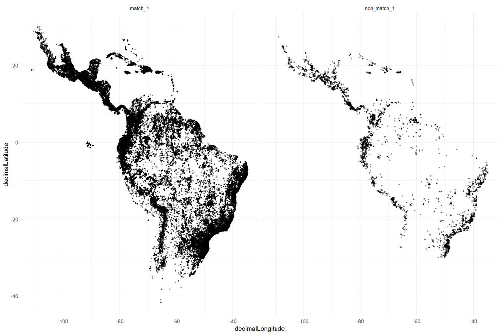

```r
library(dplyr)
library(ggplot2)

# --- 1. Define match groups ---
db_chk <- db_prev_matched %>%
  mutate(
    match_group = case_when(
      match_code == 1 ~ "match_1_exact",
      match_code == 2 ~ "match_2_fuzzy",
      match_code == 3 ~ "match_3_loose",
      is.na(match_code) | match_code == 0 ~ "no_match",
      TRUE ~ "other"
    ),
    lost_flag = ifelse(match_code == 1, "kept", "lost")
  )

# --- 2. GLOBAL SUMMARY (records) ---
summary_records <- db_chk %>%
  count(match_group) %>%
  mutate(prop = n / sum(n))

# --- 3. SPECIES LOSS ---
species_loss <- db_chk %>%
  group_by(scientificName) %>%
  summarise(
    total_records = n(),
    n_match1 = sum(match_code == 1, na.rm = TRUE),
    n_lost = sum(match_code != 1 | is.na(match_code)),
    prop_lost = n_lost / total_records,
    .groups = "drop"
  )

species_completely_lost <- species_loss %>%
  filter(n_match1 == 0)

# --- 4. FAMILY LEVEL (records + species) ---
loss_by_family <- db_chk %>%
  group_by(family) %>%
  summarise(
    total_records = n(),
    lost_records = sum(match_code != 1 | is.na(match_code)),
    prop_records_lost = lost_records / total_records,
    n_species_total = n_distinct(scientificName),
    .groups = "drop"
  ) %>%
  left_join(
    db_chk %>%
      group_by(family, scientificName) %>%
      summarise(
        has_match1 = any(match_code == 1, na.rm = TRUE),
        .groups = "drop"
      ) %>%
      group_by(family) %>%
      summarise(
        n_species_lost = sum(!has_match1),
        .groups = "drop"
      ),
    by = "family"
  ) %>%
  mutate(
    prop_species_lost = n_species_lost / n_species_total
  ) %>%
  arrange(desc(lost_records))

# --- 5. GENUS LEVEL (records + species) ---
loss_by_genus <- db_chk %>%
  group_by(genus) %>%
  summarise(
    total_records = n(),
    lost_records = sum(match_code != 1 | is.na(match_code)),
    prop_records_lost = lost_records / total_records,
    n_species_total = n_distinct(scientificName),
    .groups = "drop"
  ) %>%
  left_join(
    db_chk %>%
      group_by(genus, scientificName) %>%
      summarise(
        has_match1 = any(match_code == 1, na.rm = TRUE),
        .groups = "drop"
      ) %>%
      group_by(genus) %>%
      summarise(
        n_species_lost = sum(!has_match1),
        .groups = "drop"
      ),
    by = "genus"
  ) %>%
  mutate(
    prop_species_lost = n_species_lost / n_species_total
  ) %>%
  arrange(desc(lost_records))

# --- 6. SPATIAL PATTERN ---
map_data <- db_chk %>%
  filter(!is.na(decimalLatitude), !is.na(decimalLongitude)) %>%
  mutate(match_binary = ifelse(match_code == 1, "match_1", "non_match_1"))

ggplot(map_data, aes(x = decimalLongitude, y = decimalLatitude)) +
  geom_point(alpha = 0.4, size = 0.7) +
  facet_wrap(~match_binary) +
  theme_minimal()
```

```r
db_chk <- db_prev_matched %>%
  mutate(
    lost = is.na(match_code) | match_code != 1
  )

# Species-level status
species_status <- db_chk %>%
  group_by(family, genus, scientificName) %>%
  summarise(
    total_records = n(),
    lost_records = sum(lost),
    kept_records = sum(!lost),
    completely_lost = all(lost),
    .groups = "drop"
  )

# Family table with lost species names
loss_by_family <- species_status %>%
  group_by(family) %>%
  summarise(
    total_records = sum(total_records),
    lost_records = sum(lost_records),
    prop_records_lost = lost_records / total_records,
    n_species_total = n_distinct(scientificName),
    n_species_lost = sum(completely_lost),
    prop_species_lost = n_species_lost / n_species_total,
    species_lost = paste(scientificName[completely_lost], collapse = "; "),
    .groups = "drop"
  ) %>%
  arrange(desc(lost_records))

# Genus table with lost species names
loss_by_genus <- species_status %>%
  group_by(family, genus) %>%
  summarise(
    total_records = sum(total_records),
    lost_records = sum(lost_records),
    prop_records_lost = lost_records / total_records,
    n_species_total = n_distinct(scientificName),
    n_species_lost = sum(completely_lost),
    prop_species_lost = n_species_lost / n_species_total,
    species_lost = paste(scientificName[completely_lost], collapse = "; "),
    .groups = "drop"
  ) %>%
  arrange(desc(lost_records))

head(loss_by_family, 20)
```

```
# A tibble: 5 × 8
  family        total_records lost_records prop_records_lost n_species_total
  <chr>                 <int>        <int>             <dbl>           <int>
1 Orchidaceae          236927         2978           0.0126             7937
2 Polypodiaceae        107545         2416           0.0225              599
3 Bromeliaceae         116542         1933           0.0166             1590
4 Araceae               75434         1109           0.0147              675
5 Piperaceae            45400          135           0.00297             439
# ℹ 3 more variables: n_species_lost <int>, prop_species_lost <dbl>,
#   species_lost <chr>
```

```r
head(loss_by_genus, 20)
```

```
# A tibble: 20 × 9
   family     genus total_records lost_records prop_records_lost n_species_total
   <chr>      <chr>         <int>        <int>             <dbl>           <int>
 1 Polypodia… Serp…         13256          904           0.0682               43
 2 Araceae    Anth…         63904          622           0.00973             616
 3 Polypodia… Terp…          2417          527           0.218                26
 4 Araceae    Phil…          9017          487           0.0540               45
 5 Bromeliac… Till…         50874          407           0.00800             509
 6 Bromeliac… Cato…          3510          398           0.113                19
 7 Polypodia… Camp…         16261          395           0.0243               52
 8 Bromeliac… Vrie…         18205          355           0.0195              277
 9 Orchidace… Gome…          6513          343           0.0527               96
10 Orchidace… Epid…         30780          342           0.0111              987
11 Bromeliac… Hohe…          1003          341           0.340                32
12 Orchidace… Noty…           920          327           0.355                40
13 Bromeliac… Aech…         17873          272           0.0152              231
14 Polypodia… Poly…          2634          268           0.102                29
15 Orchidace… Cama…          4622          204           0.0441               74
16 Polypodia… Zygo…           200          150           0.75                  6
17 Orchidace… Stel…         14684          149           0.0101              781
18 Polypodia… Sten…           779          139           0.178                13
19 Piperaceae Pepe…         45323          135           0.00298             438
20 Orchidace… Elle…          5066          132           0.0261               86
# ℹ 3 more variables: n_species_lost <int>, prop_species_lost <dbl>,
#   species_lost <chr>
```

```r
# --- OUTPUTS ---
summary_records
```

```
    match_group      n         prop
1 match_1_exact 573277 0.9852693487
2 match_2_fuzzy   5763 0.0099046486
3 match_3_loose   2730 0.0046919470
4      no_match     78 0.0001340556
```

```r
head(species_completely_lost, 20)
```

```
# A tibble: 20 × 5
   scientificName             total_records n_match1 n_lost prop_lost
   <chr>                              <int>    <int>  <int>     <dbl>
 1 Acianthera brachiloba                  6        0      6         1
 2 Acianthera per-dusenii               110        0    110         1
 3 Acineta barkeri                      130        0    130         1
 4 Aechmea lamarchei                    257        0    257         1
 5 Aechmea leonard-kentiana              15        0     15         1
 6 Anthurium ceratiinum                 108        0    108         1
 7 Anthurium coerulescens                 5        0      5         1
 8 Anthurium conbeimense                  3        0      3         1
 9 Anthurium gaudichaudianum            345        0    345         1
10 Anthurium gonzalezii                   7        0      7         1
11 Anthurium holm-nielsenii              17        0     17         1
12 Anthurium macleani                   107        0    107         1
13 Anthurium subcoerulescens             30        0     30         1
14 Barbosella circinata                   2        0      2         1
15 Barkeria barkeriola                   19        0     19         1
16 Beclardia macrostachys                58        0     58         1
17 Billbergia meyeri                     32        0     32         1
18 Brassia allenii                       16        0     16         1
19 Brassia thyrsodes                      9        0      9         1
20 Bulbophyllum campos-portoi            11        0     11         1
```

```r
head(loss_by_family, 20)
```

```
# A tibble: 5 × 8
  family        total_records lost_records prop_records_lost n_species_total
  <chr>                 <int>        <int>             <dbl>           <int>
1 Orchidaceae          236927         2978           0.0126             7937
2 Polypodiaceae        107545         2416           0.0225              599
3 Bromeliaceae         116542         1933           0.0166             1590
4 Araceae               75434         1109           0.0147              675
5 Piperaceae            45400          135           0.00297             439
# ℹ 3 more variables: n_species_lost <int>, prop_species_lost <dbl>,
#   species_lost <chr>
```

```r
head(loss_by_genus, 20)
```

```
# A tibble: 20 × 9
   family     genus total_records lost_records prop_records_lost n_species_total
   <chr>      <chr>         <int>        <int>             <dbl>           <int>
 1 Polypodia… Serp…         13256          904           0.0682               43
 2 Araceae    Anth…         63904          622           0.00973             616
 3 Polypodia… Terp…          2417          527           0.218                26
 4 Araceae    Phil…          9017          487           0.0540               45
 5 Bromeliac… Till…         50874          407           0.00800             509
 6 Bromeliac… Cato…          3510          398           0.113                19
 7 Polypodia… Camp…         16261          395           0.0243               52
 8 Bromeliac… Vrie…         18205          355           0.0195              277
 9 Orchidace… Gome…          6513          343           0.0527               96
10 Orchidace… Epid…         30780          342           0.0111              987
11 Bromeliac… Hohe…          1003          341           0.340                32
12 Orchidace… Noty…           920          327           0.355                40
13 Bromeliac… Aech…         17873          272           0.0152              231
14 Polypodia… Poly…          2634          268           0.102                29
15 Orchidace… Cama…          4622          204           0.0441               74
16 Polypodia… Zygo…           200          150           0.75                  6
17 Orchidace… Stel…         14684          149           0.0101              781
18 Polypodia… Sten…           779          139           0.178                13
19 Piperaceae Pepe…         45323          135           0.00298             438
20 Orchidace… Elle…          5066          132           0.0261               86
# ℹ 3 more variables: n_species_lost <int>, prop_species_lost <dbl>,
#   species_lost <chr>
```

comparing with new dataset

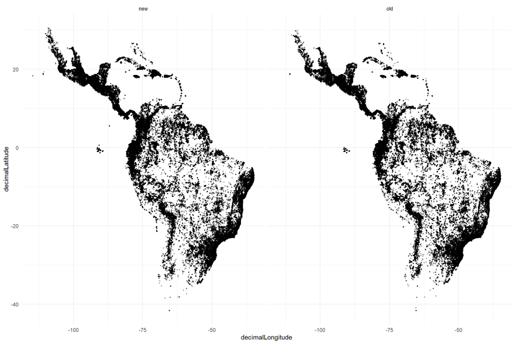

```r
library(dplyr)
library(ggplot2)

# --- 1. Prepare datasets ---
old <- db_prev_matched %>%
  filter(match_code == 1) %>%
  select(scientificName, family, genus, decimalLatitude, decimalLongitude)

new <- db_filtered %>%
  filter(matchCodeEpig == "1") %>%  # should already be all 1
  select(scientificName, family, genus, decimalLatitude, decimalLongitude)

# --- 2. BASIC SIZE ---
summary_sizes <- tibble(
  dataset = c("old", "new"),
  n_records = c(nrow(old), nrow(new)),
  n_species = c(n_distinct(old$scientificName),
                n_distinct(new$scientificName))
)

# --- 3. SPECIES COMPARISON (THIS IS THE CORE) ---
spp_old <- old %>% distinct(scientificName)
spp_new <- new %>% distinct(scientificName)

species_lost <- spp_old %>%
  anti_join(spp_new, by = "scientificName")

species_gained <- spp_new %>%
  anti_join(spp_old, by = "scientificName")

species_shared <- inner_join(spp_old, spp_new, by = "scientificName")

species_summary <- tibble(
  metric = c("old", "new", "shared", "lost", "gained"),
  n = c(nrow(spp_old),
        nrow(spp_new),
        nrow(species_shared),
        nrow(species_lost),
        nrow(species_gained))
)

# --- 4. TAXONOMIC SIGNAL ---
loss_by_family <- old %>%
  semi_join(species_lost, by = "scientificName") %>%
  group_by(family) %>%
  summarise(
    lost_records = n(),
    lost_species = n_distinct(scientificName),
    .groups = "drop"
  ) %>%
  arrange(desc(lost_records))

gain_by_family <- new %>%
  semi_join(species_gained, by = "scientificName") %>%
  group_by(family) %>%
  summarise(
    gained_records = n(),
    gained_species = n_distinct(scientificName),
    .groups = "drop"
  ) %>%
  arrange(desc(gained_records))

# --- 5. SPATIAL COMPARISON ---
map_data <- bind_rows(
  old %>% mutate(dataset = "old"),
  new %>% mutate(dataset = "new")
) %>%
  filter(!is.na(decimalLatitude), !is.na(decimalLongitude))

ggplot(map_data, aes(decimalLongitude, decimalLatitude)) +
  geom_point(alpha = 0.3, size = 0.6) +
  facet_wrap(~dataset) +
  theme_minimal()
```

```r
# --- OUTPUTS ---
summary_sizes
```

```
# A tibble: 2 × 3
  dataset n_records n_species
  <chr>       <int>     <int>
1 old        573277     11106
2 new        562806     12176
```

```r
species_summary
```

```
# A tibble: 5 × 2
  metric     n
  <chr>  <int>
1 old    11106
2 new    12176
3 shared 10159
4 lost     947
5 gained  2017
```

```r
head(species_lost, 20)
```

```
                       scientificName
1                Leptochilus insignis
2                   Catopsis wawreana
3     Guzmania lindenii var. lindenii
4  Aechmea longicuspis var. kuntzeana
5              Billbergia chlorostica
6                 Octomeria taracuana
7         Encyclia patens var. patens
8               Maxillaria chrysantha
9                 Cypholoron frigidum
10              Maxillaria breviscapa
11                Maxillaria disticha
12            Maxillaria poicilothece
13              Loxogramme lanceolata
14                  Maxillaria albata
15              Maxillaria brachypoda
16                   Goodyera procera
17             Epidendrum blancheanum
18                Selliguea laciniata
19        Brachionidium yanachagaense
20                   Stelis decipiens
```

```r
head(species_gained, 20)
```

```
# A tibble: 20 × 1
   scientificName
   <chr>
 1 Anthurium apaporanum
 2 Anthurium croatii
 3 Anthurium eminens
 4 Anthurium ernestii
 5 Anthurium formosum
 6 Anthurium longistrorsum
 7 Anthurium pseudoclavigerum
 8 Anthurium uleanum
 9 Philodendron acreanum
10 Philodendron aureimarginatum
11 Philodendron barrosoanum
12 Philodendron brevispathum
13 Philodendron campii
14 Philodendron camposportoanum
15 Philodendron deltoideum
16 Philodendron ernestii
17 Philodendron exile
18 Philodendron grazielae
19 Philodendron guttiferum
20 Philodendron heleniae
```

```r
head(loss_by_family, 20)
```

```
# A tibble: 5 × 3
  family        lost_records lost_species
  <chr>                <int>        <int>
1 Orchidaceae           6909          836
2 Polypodiaceae         1160           53
3 Piperaceae             675           26
4 Bromeliaceae           576           21
5 Araceae                 32           11
```

```r
head(gain_by_family, 20)
```

```
# A tibble: 5 × 3
  family        gained_records gained_species
  <chr>                  <int>          <int>
1 Araceae                41634            875
2 Bromeliaceae            8761            310
3 Orchidaceae             7959            634
4 Polypodiaceae           6208            120
5 Piperaceae              4020             78
```

# Plots to export

```r
# library(tidyverse)
# library(sf)
# library(ggplot2)
# library(plotly)
# library(viridis)
# library(gridExtra)
#
# # Create figures directory
# dir.create("figures", showWarnings = FALSE)
#
# # ============================================================================
# # SETUP: Prepare data summaries for fast visualization
# # ============================================================================
#
# # Basic checks
# cat("Total records:", nrow(db), "\n")
# cat("Records with valid coordinates:", sum(!is.na(db$decimalLatitude) & !is.na(db$decimalLongitude)), "\n")
# cat("Unique families:", n_distinct(db$family), "\n")
# cat("Unique genera:", n_distinct(db$genus), "\n")
# cat("Year range:", min(db$year, na.rm = TRUE), "-", max(db$year, na.rm = TRUE), "\n")
#
# # ============================================================================
# # MAPS
# # ============================================================================
#
# cat("\n=== CREATING MAPS ===\n")
#
# # Prepare coordinates with valid data
# db_coords <- db %>%
#   filter(!is.na(decimalLatitude) & !is.na(decimalLongitude)) %>%
#   filter(decimalLatitude >= -90 & decimalLatitude <= 90,
#          decimalLongitude >= -180 & decimalLongitude <= 180)
#
# cat("Valid coordinates:", nrow(db_coords), "\n")
#
# # --- 1. DOT DENSITY MAP (sample 50K for performance)
# cat("Creating dot density map...\n")
# set.seed(4821)
# db_sample <- db_coords %>% slice_sample(n = min(50000, nrow(db_coords)))
#
# p_density <- ggplot(db_sample, aes(x = decimalLongitude, y = decimalLatitude, color = source_group)) +
#   geom_point(size = 0.5, alpha = 0.3) +
#   coord_fixed() +
#   scale_color_viridis_d(option = "turbo") +
#   theme_minimal() +
#   labs(title = "Geographic Distribution of Occurrence Points",
#        subtitle = sprintf("Sample of %d from %d total points with valid coordinates",
#                           nrow(db_sample), nrow(db_coords)),
#        x = "Longitude", y = "Latitude", color = "Source Group") +
#   theme(legend.position = "bottom",
#         plot.title = element_text(face = "bold", size = 14),
#         plot.subtitle = element_text(size = 11))
#
# ggsave("figures/01_dot_density_map.png", p_density, width = 15, height = 10, dpi = 300)
# cat("✓ Saved: 01_dot_density_map.png\n")
#
# # --- 2. COUNTRY CHOROPLETH (record counts by country)
# cat("Creating country choropleth...\n")
#
# country_counts <- db %>%
#   filter(!is.na(country)) %>%
#   count(country) %>%
#   arrange(desc(n)) %>%
#   head(30)
#
# p_country <- ggplot(country_counts, aes(x = reorder(country, n), y = n, fill = n)) +
#   geom_col() +
#   coord_flip() +
#   scale_fill_viridis_c(direction = -1) +
#   theme_minimal() +
#   labs(title = "Record Count by Country (Top 30)",
#        subtitle = "Brazil and Mexico dominate; clear Neotropical bias",
#        x = "Country", y = "Number of Records", fill = "Records") +
#   theme(plot.title = element_text(face = "bold", size = 14))
#
# ggsave("figures/02_country_distribution.png", p_country, width = 12, height = 10, dpi = 300)
# cat("✓ Saved: 02_country_distribution.png\n")
#
# # --- 3. SPECIES RICHNESS GRID (1° cells)
# cat("Creating species richness grid...\n")
#
# richness_grid <- db_coords %>%
#   filter(!is.na(scientificName)) %>%
#   mutate(
#     lat_cell = floor(decimalLatitude),
#     lon_cell = floor(decimalLongitude)
#   ) %>%
#   group_by(lat_cell, lon_cell) %>%
#   summarise(
#     n_species = n_distinct(scientificName),
#     n_records = n(),
#     .groups = "drop"
#   ) %>%
#   filter(!is.na(lat_cell) & !is.na(lon_cell))
#
# p_richness <- ggplot(richness_grid, aes(x = lon_cell, y = lat_cell, fill = n_species)) +
#   geom_tile() +
#   coord_fixed() +
#   scale_fill_viridis_c(option = "viridis", direction = -1) +
#   theme_minimal() +
#   labs(title = "Species Richness by 1° Grid Cell",
#        subtitle = "Ecologically meaningful diversity pattern",
#        x = "Longitude", y = "Latitude", fill = "Unique Species") +
#   theme(plot.title = element_text(face = "bold", size = 14))
#
# ggsave("figures/03_species_richness_grid.png", p_richness, width = 15, height = 10, dpi = 300)
# cat("✓ Saved: 03_species_richness_grid.png\n")
#
# # ============================================================================
# # TAXONOMIC VISUALIZATIONS
# # ============================================================================
#
# cat("\n=== CREATING TAXONOMIC VISUALIZATIONS ===\n")
#
# # --- 4. TREEMAP (Families by record count)
# cat("Creating treemap...\n")
#
# family_counts <- db %>%
#   filter(!is.na(family)) %>%
#   count(family) %>%
#   arrange(desc(n)) %>%
#   mutate(pct = round(100 * n / sum(n), 1))
#
# # Create treemap manually since treemapify may not be available
# p_treemap <- ggplot(family_counts, aes(area = n, fill = n, label = paste0(family, "\n", n))) +
#   geom_treemap() +
#   geom_treemap_text(fontface = "italic", colour = "white", place = "centre") +
#   scale_fill_viridis_c(direction = -1) +
#   theme(plot.title = element_text(face = "bold", size = 14)) +
#   labs(title = "Taxonomic Distribution: Plant Families",
#        subtitle = "Orchidaceae and Bromeliaceae dominate",
#        fill = "Record Count")
#
# ggsave("figures/04_family_treemap.png", p_treemap, width = 14, height = 10, dpi = 300)
# cat("✓ Saved: 04_family_treemap.png\n")
#
# # --- 5. TOP 20 GENERA (horizontal bar chart with order coloring)
# cat("Creating top 20 genera chart...\n")
#
# genus_counts <- db %>%
#   filter(!is.na(genus) & !is.na(order)) %>%
#   count(genus, order) %>%
#   arrange(desc(n)) %>%
#   head(20)
#
# p_genera <- ggplot(genus_counts, aes(x = reorder(genus, n), y = n, fill = order)) +
#   geom_col() +
#   coord_flip() +
#   scale_fill_viridis_d(option = "turbo") +
#   theme_minimal() +
#   labs(title = "Top 20 Most Recorded Genera",
#        x = "Genus", y = "Number of Records", fill = "Order") +
#   theme(plot.title = element_text(face = "bold", size = 14))
#
# ggsave("figures/05_top_genera.png", p_genera, width = 12, height = 10, dpi = 300)
# cat("✓ Saved: 05_top_genera.png\n")
#
# # --- 6. TOP 20 FAMILIES (horizontal bar chart)
# cat("Creating top 20 families chart...\n")
#
# top_families <- family_counts %>% head(20)
#
# p_families <- ggplot(top_families, aes(x = reorder(family, n), y = n, fill = n)) +
#   geom_col() +
#   coord_flip() +
#   scale_fill_viridis_c(direction = -1) +
#   theme_minimal() +
#   labs(title = "Top 20 Plant Families",
#        x = "Family", y = "Number of Records", fill = "Records") +
#   theme(plot.title = element_text(face = "bold", size = 14))
#
# ggsave("figures/06_top_families.png", p_families, width = 12, height = 9, dpi = 300)
# cat("✓ Saved: 06_top_families.png\n")
#
# # ============================================================================
# # TEMPORAL VISUALIZATIONS
# # ============================================================================
#
# cat("\n=== CREATING TEMPORAL VISUALIZATIONS ===\n")
#
# # --- 7. COLLECTION EFFORT TIMELINE (records per year)
# cat("Creating timeline...\n")
#
# timeline <- db %>%
#   filter(!is.na(year)) %>%
#   mutate(year = as.numeric(year)) %>%
#   filter(year >= 1692 & year <= 2026) %>%
#   count(year) %>%
#   arrange(year)
#
# p_timeline <- ggplot(timeline, aes(x = year, y = n)) +
#   geom_area(fill = "steelblue", alpha = 0.6) +
#   geom_line(color = "steelblue", size = 1) +
#   theme_minimal() +
#   labs(title = "Collection Effort Over Time",
#        subtitle = "Peak in 1980s–2000s; recent decline likely due to lag in data processing",
#        x = "Year", y = "Number of Records") +
#   theme(plot.title = element_text(face = "bold", size = 14)) +
#   scale_x_continuous(breaks = seq(1700, 2026, 50))
#
# ggsave("figures/07_timeline.png", p_timeline, width = 14, height = 7, dpi = 300)
# cat("✓ Saved: 07_timeline.png\n")
#
# # --- 8. RECORDS BY DECADE AND SOURCE
# cat("Creating decade × source heatmap...\n")
#
# decade_source <- db %>%
#   filter(!is.na(year) & !is.na(source_group)) %>%
#   mutate(year = as.numeric(year)) %>%
#   filter(year >= 1692 & year <= 2026) %>%
#   mutate(decade = floor(year / 10) * 10) %>%
#   count(decade, source_group) %>%
#   arrange(decade)
#
# p_heatmap <- ggplot(decade_source, aes(x = decade, y = source_group, fill = n)) +
#   geom_tile() +
#   scale_fill_viridis_c(direction = -1) +
#   theme_minimal() +
#   labs(title = "Collection Effort: Decade × Source Group",
#        x = "Decade", y = "Source Group", fill = "Records") +
#   theme(plot.title = element_text(face = "bold", size = 14),
#         axis.text.x = element_text(angle = 45, hjust = 1))
#
# ggsave("figures/08_decade_source_heatmap.png", p_heatmap, width = 12, height = 7, dpi = 300)
# cat("✓ Saved: 08_decade_source_heatmap.png\n")
#
# # ============================================================================
# # DATA QUALITY VISUALIZATIONS
# # ============================================================================
#
# cat("\n=== CREATING DATA QUALITY VISUALIZATIONS ===\n")
#
# # --- 9. FIELD COMPLETENESS
# cat("Creating field completeness chart...\n")
#
# key_fields <- c("decimalLatitude", "decimalLongitude", "year", "locality",
#                 "minimumElevationInMeters", "family", "genus")
#
# completeness <- tibble(
#   Field = key_fields,
#   Completeness = sapply(key_fields, function(col) {
#     sum(!is.na(db[[col]])) / nrow(db) * 100
#   })
# ) %>%
#   arrange(Completeness)
#
# p_completeness <- ggplot(completeness, aes(x = reorder(Field, Completeness), y = Completeness, fill = Completeness)) +
#   geom_col() +
#   coord_flip() +
#   scale_fill_viridis_c(direction = -1) +
#   geom_text(aes(label = paste0(round(Completeness, 1), "%")), hjust = -0.1, size = 4) +
#   theme_minimal() +
#   ylim(0, 110) +
#   labs(title = "Field Completeness Across Key Data Fields",
#        subtitle = "Strong geographic core (coords, year), weaker periphery (elevation, genus)",
#        x = "Field", y = "Completeness (%)", fill = "Completeness") +
#   theme(plot.title = element_text(face = "bold", size = 14),
#         legend.position = "bottom")
#
# ggsave("figures/09_field_completeness.png", p_completeness, width = 11, height = 7, dpi = 300)
# cat("✓ Saved: 09_field_completeness.png\n")
#
# # --- 10. DATA QUALITY BY SOURCE GROUP
# cat("Creating quality by source group...\n")
#
# quality_by_source <- db %>%
#   group_by(source_group) %>%
#   summarise(
#     coords = sum(!is.na(decimalLatitude) & !is.na(decimalLongitude)) / n() * 100,
#     year = sum(!is.na(year)) / n() * 100,
#     locality = sum(!is.na(locality)) / n() * 100,
#     elevation = sum(!is.na(minimumElevationInMeters)) / n() * 100,
#     .groups = "drop"
#   ) %>%
#   pivot_longer(-source_group, names_to = "field", values_to = "completeness")
#
# p_quality_source <- ggplot(quality_by_source, aes(x = source_group, y = completeness, fill = field)) +
#   geom_col(position = "dodge") +
#   coord_flip() +
#   scale_fill_viridis_d(option = "turbo") +
#   theme_minimal() +
#   labs(title = "Data Quality by Source Group",
#        x = "Source Group", y = "Field Completeness (%)", fill = "Field") +
#   theme(plot.title = element_text(face = "bold", size = 14))
#
# ggsave("figures/10_quality_by_source.png", p_quality_source, width = 12, height = 8, dpi = 300)
# cat("✓ Saved: 10_quality_by_source.png\n")
#
# # ============================================================================
# # SOURCE COMPOSITION
# # ============================================================================
#
# cat("\n=== CREATING SOURCE COMPOSITION VISUALIZATIONS ===\n")
#
# # --- 11. SOURCE GROUP COMPOSITION (waffle-style or donut)
# cat("Creating source composition chart...\n")
#
# source_comp <- db %>%
#   count(source_group) %>%
#   arrange(desc(n)) %>%
#   mutate(pct = round(100 * n / sum(n), 1))
#
# p_source <- ggplot(source_comp, aes(x = "", y = n, fill = source_group)) +
#   geom_col(width = 1) +
#   coord_polar("y", start = 0) +
#   geom_text(aes(label = paste0(source_group, "\n", pct, "%")),
```

```r
#             position = position_stack(vjust = 0.5), size = 4) +
#   scale_fill_viridis_d(option = "turbo") +
#   theme_void() +
#   labs(title = "Data Source Composition",
#        subtitle = sprintf("Total: %d records across %d sources", nrow(db), nrow(source_comp))) +
#   theme(plot.title = element_text(face = "bold", size = 14, hjust = 0.5),
#         plot.subtitle = element_text(hjust = 0.5),
#         legend.position = "none")
#
# ggsave("figures/11_source_composition.png", p_source, width = 10, height = 8, dpi = 300)
# cat("✓ Saved: 11_source_composition.png\n")
#
# # --- 12. SOURCE GROUP BAR CHART
# cat("Creating source group bar chart...\n")
#
# p_source_bar <- ggplot(source_comp, aes(x = reorder(source_group, n), y = n, fill = n)) +
#   geom_col() +
#   coord_flip() +
#   scale_fill_viridis_c(direction = -1) +
#   geom_text(aes(label = paste0(n, " (", pct, "%)")), hjust = -0.1, size = 4) +
#   theme_minimal() +
#   ylim(0, max(source_comp$n) * 1.1) +
#   labs(title = "Records by Source Group",
#        x = "Source Group", y = "Number of Records", fill = "Records") +
#   theme(plot.title = element_text(face = "bold", size = 14))
#
# ggsave("figures/12_source_group_distribution.png", p_source_bar, width = 12, height = 8, dpi = 300)
# cat("✓ Saved: 12_source_group_distribution.png\n")
#
# # ============================================================================
# # SUMMARY STATISTICS TABLE
# # ============================================================================
#
# cat("\n=== CREATING SUMMARY TABLE ===\n")
#
# summary_stats <- tibble(
#   Metric = c(
#     "Total Records",
#     "Records with Valid Coordinates",
#     "Unique Families",
#     "Unique Genera",
#     "Unique Species",
#     "Countries Represented",
#     "Year Range",
#     "Median Year",
#     "Source Groups"
#   ),
#   Value = c(
#     format(nrow(db), big.mark = ","),
#     format(nrow(db_coords), big.mark = ","),
#     n_distinct(db$family, na.rm = TRUE),
#     n_distinct(db$genus, na.rm = TRUE),
#     n_distinct(db$scientificName, na.rm = TRUE),
#     n_distinct(db$country, na.rm = TRUE),
#     paste0(min(db$year, na.rm = TRUE), " – ", max(db$year, na.rm = TRUE)),
#     round(median(as.numeric(db$year), na.rm = TRUE)),
#     n_distinct(db$source_group, na.rm = TRUE)
#   )
# )
#
# write_csv(summary_stats, "figures/summary_statistics.csv")
# cat("✓ Saved: summary_statistics.csv\n")
#
# cat("\n" %+% paste(rep("=", 80), collapse = ""))
# cat("\n✓ ALL VISUALIZATIONS CREATED SUCCESSFULLY")
# cat("\nOutput folder: figures/\n")
# cat("\nGenerated files:\n")
# system("ls -1 figures/ | grep -E '\\.(png|csv)$'")
```